# The Milestone Report

N. Kirnosov

# Introduction

In this milestone report we will cover basic data acquisition, elucidate its structure, perform some exploratory analysis and discuss the findings. Also, a vision of the word suggesting mechanism will be presented.

# Getting Data

The data set was downloaded from the [link provided](https://d396qusza40orc.cloudfront.net/dsscapstone/dataset/Coursera-SwiftKey.zip) on the course web site. English directory was used to create Twitter, News, and Blogs text samples. Also, for future use, [google-banned words](https://gist.github.com/jamiew/1112488/raw/7ca9b1669e1c24b27c66174762cb04e14cf05aa7/google_twunter_lol) were read.

# Files Summary

Some basic features of the available data sets are shown below.

Summary of the datasets

|  | # of lines | memory allocated, MB | Median message length | Max message length |
| --- | --- | --- | --- | --- |
| twits | 2360148 | 301 | 64 | 140 |
| news | 1010242 | 250 | 185 | 11384 |
| blogs | 899288 | 248 | 156 | 40833 |

After reading a few data entries from each goup, we can suggest:

- twits are short (no longer than 140) and are known to have lots of informal lexicon,
- news are more formal, but topics covered are somewhat narrow,
- the style of blogs is between twitter and news styles.

From the data processing standpoint we can note that while twits come in the biggest file and news have the greatest meadian number of characters per entry, blogs pocessing is likely to present the biggest challenge due to the presence of very long messages.

# Tokenization

- change the text to lower case,
- remove punctuation,
- remove numbers,
- remove urls,
- remove profanity words,
- remove stop words, and
- stem the document.

Next, `NGramTokenizer` from `RWeka` package will be used to create 1, 2, 3, and 4 gram tokens.

All the sample processing and tokenization is done inside the `get_tokens` function. Using this function, we can work around memory limitations and process the files of virtually any size by varying `step` value in the `get_grams` function.

We will sample 100,000 messages from each data set. Data will be processed in chunks of 5,000 entries and resulting n-gramms will be aggregated.

```r
sample_size=100000
step=5000
twits_grams <- get_grams(sample(twits,min(sample_size,length(twits))),step=step)
```

[output not shown]

```r
news_grams <- get_grams(sample(news,min(sample_size,length(news))),step=step)
```

[output not shown]

```r
blogs_grams <- get_grams(sample(blogs,min(sample_size,length(blogs))),step=step)
```

[output not shown]

# Style comparison

Top 10 n-Grams (n=1,..,4) for each category are shown below.

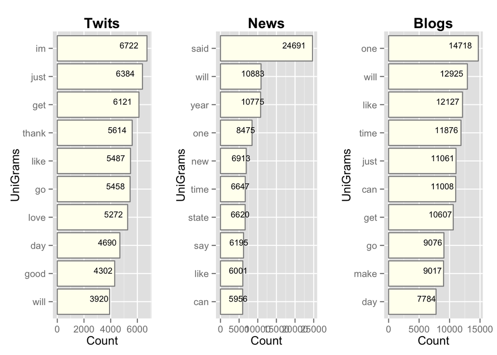

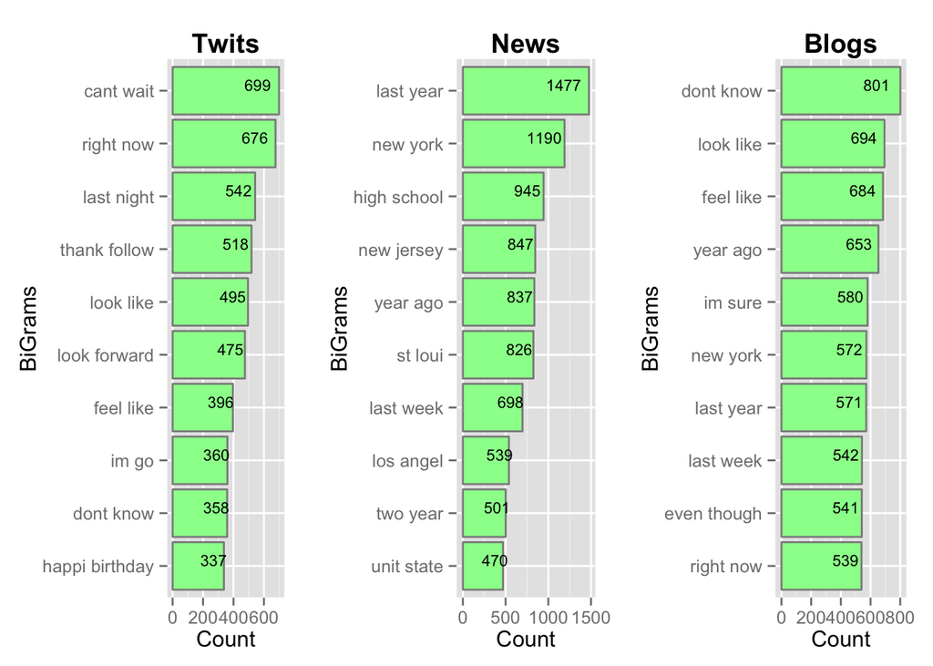

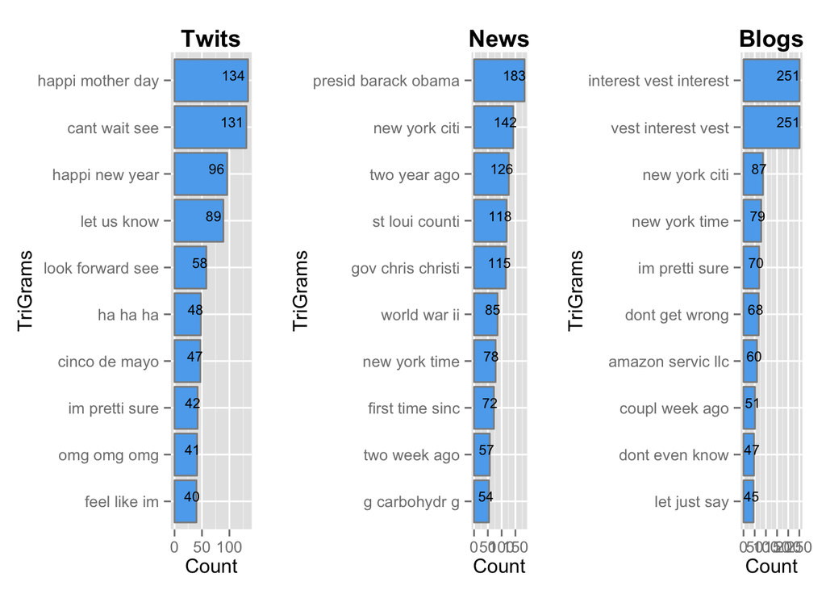

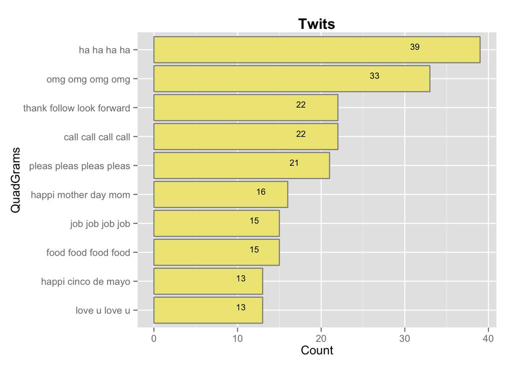

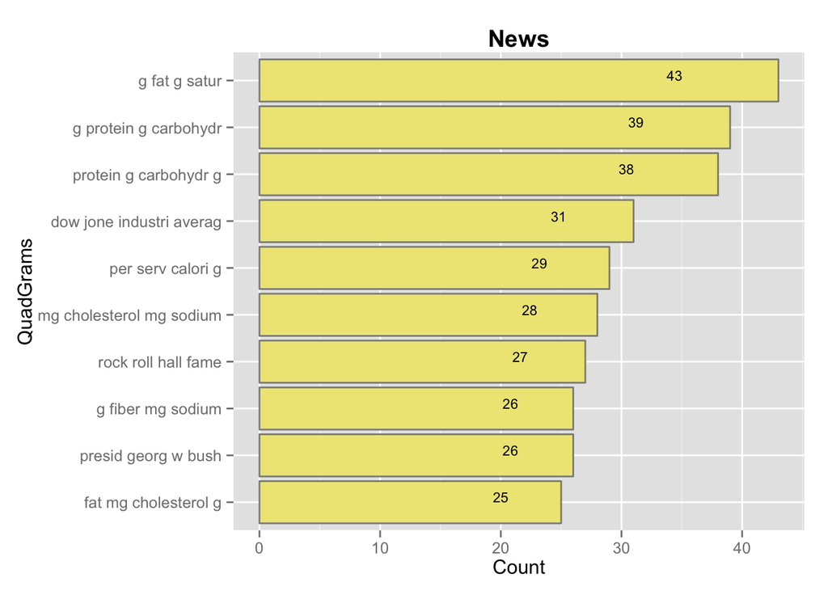

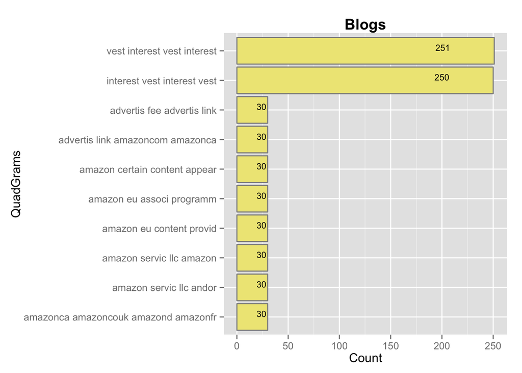

# Model development directions

From the comparison of twitter, news, and blogs styles it we can conclude that it would be wise to develop somewhat different models for different communication cases. For example, if the text is imputted into a social network message, higher weight should be given to tokens obtained from Twitter.

The model is expected to suggest words as the user types the word (e.g., if ‘unive’ is typed, ‘university’ and ‘universe’ should be suggested). This prediction will be based on the unigrams frequencies. Next, after several words will be typed in, next word prediction will be made based on n-grams frequencies, starting from n=4 and ending (if nescessary) with n=1.

Of course, more work needs to be done to produce more sensible and informative n-grams, especially from Twitter data.